# Tugas Praktikum 4

G1401231083 - Gafin Khalifa Nalya

2025-09-13

### Packages

```r
library(dLagM)
library(dynlm)
library(MLmetrics)
library(lmtest)
library(car)
```

```r
library(corrplot)
```

### Impor Data

```r
data <- read.csv("NewDelhi_Air_quality.csv")
data
```

```
##     X  AQI       CO      datetime        no2       o3      pm10     pm25
## 1   0 30.2 198.6027 2022-10-21:18 0.04685717 55.78995 10.486722 5.637410
## 2   1 28.2 197.6013 2022-10-21:19 0.04645554 54.93164 10.719325 4.618169
## 3   2 26.6 198.6027 2022-10-21:20 0.04685717 54.64554 11.155578 3.520902
## 4   3 25.0 201.9405 2022-10-21:21 0.04819594 55.07469 11.116206 2.225919
## 5   4 26.0 205.2784 2022-10-21:22 0.04886533 55.78995 10.405250 1.979471
## 6   5 26.0 208.6163 2022-10-21:23 0.05020411 56.50520  9.402518 1.792677
## 7   6 26.0 208.6163 2022-10-22:00 0.05020411 55.78995  8.482822 1.752237
## 8   7 24.0 205.2784 2022-10-22:01 0.05020411 52.92892  7.586667 1.858459
## 9   8 23.0 200.2716 2022-10-22:02 0.04685717 50.06790  7.636587 2.208076
## 10  9 24.0 196.9338 2022-10-22:03 0.04417961 51.49841  8.487648 2.476681
## 11 10 25.0 198.6027 2022-10-22:04 0.04284084 53.64418  9.357371 2.585729
## 12 11 26.0 200.2716 2022-10-22:05 0.04049798 55.78995 10.338728 2.390081
## 13 12 27.0 203.6095 2022-10-22:06 0.04016329 59.36623 10.523314 2.086022
## 14 13 29.0 205.2784 2022-10-22:07 0.03882451 62.22725 10.635970 1.937047
```

[output cut: 131 more lines]

### Korelasi

Membuat matriks korelasi dari data AQI untuk melihat peubah mana yang memiliki korelasi paling tinggi dengan peubah AQI untuk digunakan sebagai peubah X.

```r
data_numerik <- data[, sapply(data, is.numeric)]
matriks_korelasi <- cor(data_numerik, use = "complete.obs", method = "pearson")
print(matriks_korelasi)
```

```
##                X         AQI          CO        no2          o3        pm10
## X     1.00000000 -0.45387002 -0.62078757 -0.4710941 -0.38710594 -0.01967075
## AQI  -0.45387002  1.00000000  0.79763320  0.7376547  0.97359901  0.08257568
## CO   -0.62078757  0.79763320  1.00000000  0.6520228  0.82919809 -0.09598578
## no2  -0.47109406  0.73765472  0.65202279  1.0000000  0.73204188  0.25652368
## o3   -0.38710594  0.97359901  0.82919809  0.7320419  1.00000000  0.03381079
## pm10 -0.01967075  0.08257568 -0.09598578  0.2565237  0.03381079  1.00000000
## pm25  0.16599284 -0.34665524 -0.58291511 -0.3588091 -0.52197786  0.26848271
## so2   0.50412173 -0.74247813 -0.79872002 -0.5859130 -0.78562485 -0.04779446
## ts    1.00000000 -0.45387002 -0.62078757 -0.4710941 -0.38710594 -0.01967075
##            pm25         so2          ts
## X     0.1659928  0.50412173  1.00000000
## AQI  -0.3466552 -0.74247813 -0.45387002
## CO   -0.5829151 -0.79872002 -0.62078757
## no2  -0.3588091 -0.58591304 -0.47109406
## o3   -0.5219779 -0.78562485 -0.38710594
## pm10  0.2684827 -0.04779446 -0.01967075
## pm25  1.0000000  0.67434283  0.16599284
## so2   0.6743428  1.00000000  0.50412173
## ts    0.1659928  0.50412173  1.00000000
```

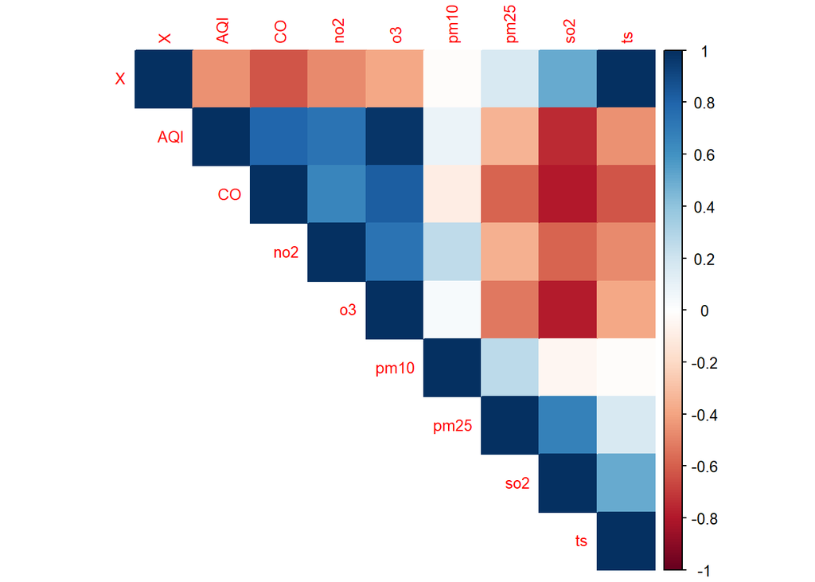

```r
corrplot(matriks_korelasi, method = "color", type = "upper", tl.cex = 0.8)
```

Kolom o3 memiliki korelasi tertinggi terhadap AQI yang merupakan peubah Y sehingga peubah o3 akan digunakan

Menurut penelitian yang ada, O3 merupakan polutan dominan penyebab kenaikan AQI pada periode panas.

Wang Y, Huang L, Huang C, Hu J, Wang M. 2023. High-resolution modeling for criteria air pollutants and the associated air quality index in a metropolitan city. Environ Int. 172 January:107752. doi:10.1016/j.envint.2023.107752.

### Pembagian Data

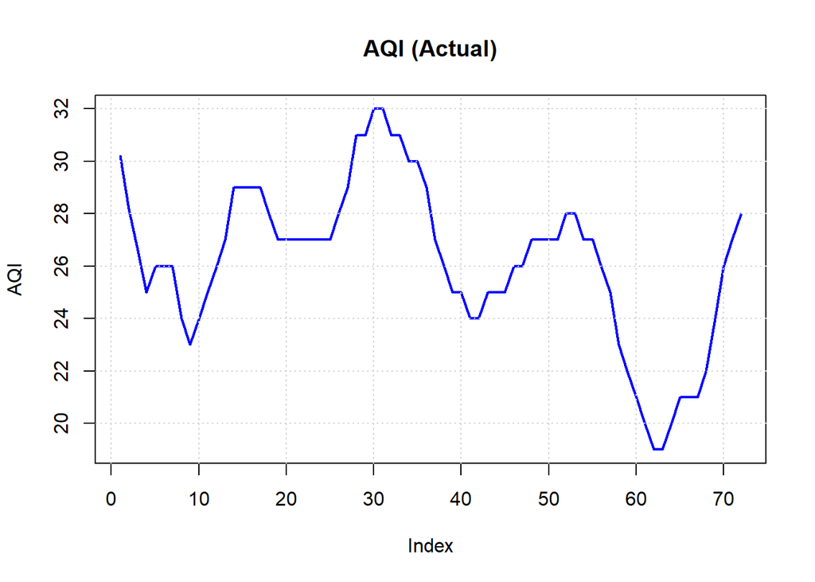

```r
# Plot AQI saja
plot(
  data$AQI, type = "l", col = "blue", lwd = 2,
  ylab = "AQI", xlab = "Index",
  main = "AQI (Actual)"
)
grid()
```

```r
train<-data[0:58,]
test<-data[59:72,]
```

Pembagian data train dan test dengan rasio 80 : 20.

```r
train.ts<-ts(train)
test.ts<-ts(test)
data.ts<-ts(data)
```

Menjadikan data time series

### Model Koyck

```r
#MODEL KOYCK
model.koyck <- koyckDlm(x = train$o3, y = train$AQI)
summary(model.koyck)
```

```
##
## Call:
## "Y ~ (Intercept) + Y.1 + X.t"
##
## Residuals:
##       Min        1Q    Median        3Q       Max
## -1.112282 -0.366467 -0.002877  0.258311  1.106529
##
## Coefficients:
##             Estimate Std. Error t value Pr(>|t|)
## (Intercept)  0.26260    0.93950   0.280    0.781
## Y.1          0.42943    0.08641   4.969 7.14e-06 ***
## X.t          0.25823    0.04259   6.064 1.35e-07 ***
## ---
## Signif. codes:  0 '***' 0.001 '**' 0.01 '*' 0.05 '.' 0.1 ' ' 1
##
## Residual standard error: 0.5239 on 54 degrees of freedom
## Multiple R-Squared: 0.9449,  Adjusted R-squared: 0.9429
## Wald test: 417.1 on 2 and 54 DF,  p-value: < 2.2e-16
##
## Diagnostic tests:
## NULL
##
##                             alpha      beta       phi
## Geometric coefficients:  0.460243 0.2582336 0.4294305
```

```r
AIC(model.koyck)
```

```
## [1] 92.98106
```

```r
BIC(model.koyck)
```

```
## [1] 101.1533
```

Interpretasi Model

X.t sangat signifikan dengan p value < 0.001 dan koefisien 0.2583. Hal ini berarti setiap kenaikan 1 satuan o3 akan meningkatkan nilai ratan dugaan AQI sebesar 0.2583 dengan mempertahankan efek jangka panjang dari Y.1

Hasil Wald test dan p-value menunjukkan model sangat signifikan secara keseluruhan.

```r
# --- Evaluasi Model Koyck dengan MAPE ---
# 1. Panjang horizon = jumlah data test
h_test <- length(test$AQI)

# 2. Forecast model dengan horizon sesuai
fore.koyck <- forecast(model = model.koyck, x = test$AQI, h = h_test)
fore.koyck
```

```
## $forecasts
##  [1] 15.820642 12.479373 10.786297  9.801005  9.377890  9.454425  9.745525
##  [8]  9.870533  9.924215 10.205501 10.842761 11.632887 12.230425 12.745260
##
## $call
## forecast.koyckDlm(model = model.koyck, x = test$AQI, h = h_test)
##
## attr(,"class")
## [1] "forecast.koyckDlm" "dLagM"
```

```r
# Ambil prediksi dan actual dalam format vektor
y_pred <- as.vector(fore.koyck$forecasts)
y_true <- as.vector(test$AQI)  # <-- ganti ke AQI

# Pastikan panjang sama
n <- min(length(y_pred), length(y_true))
y_pred <- y_pred[1:n]
y_true <- y_true[1:n]

# Hitung MAPE
mape.koyck <- mean(abs((y_true - y_pred) / y_true)) * 100

cat("MAPE Koyck Model (%):", round(mape.koyck, 2), "\n")
```

```
## MAPE Koyck Model (%): 49.91
```

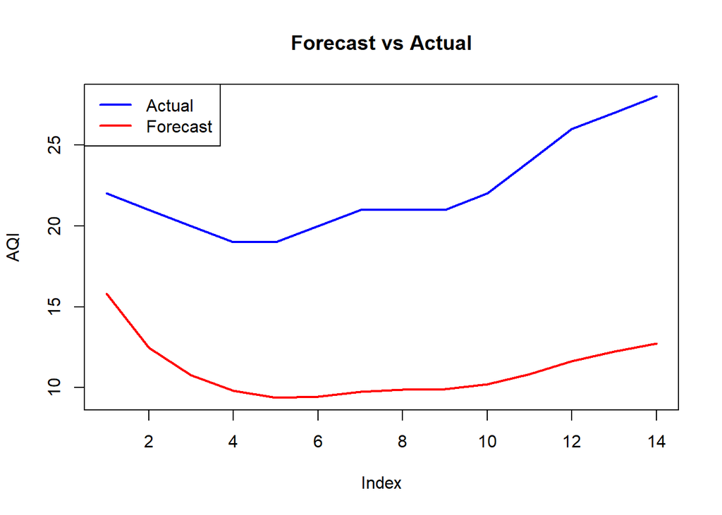

```r
plot(
  y_true, type="l", col="blue", lwd=2, ylab="AQI",
  main="Forecast vs Actual",
  ylim = range(c(y_true, y_pred), na.rm = TRUE)
)
lines(y_pred, col="red", lwd=2)
legend("topleft", legend=c("Actual","Forecast"),
       col=c("blue","red"), lty=1, lwd=2)
```

Hasil ini menunjukkan bahwa rata-rata kesalahan prediksi model Koyck adalah sekitar 49.91% dari nilai AQI aktual. Dengan MAPE ≈ 49.91%, model Koyck termasuk cukup, tapi mendekati kategori buruk. Ini berarti prediksi model masih cukup jauh dari nilai aktual — hampir setengah dari nilai AQI aktual rata-rata meleset.

Garis biru (aktual) selalu jauh di atas merah (prediksi) → model cenderung underestimate AQI. Trend arah (naik-turun) lumayan mengikuti, tapi besaran nilai terlalu rendah.

```r
GoF(model.koyck)
```

```
##              n     MAE           MPE       MAPE      sMAPE      MASE      MSE
## model.koyck 57 0.39765 -0.0005611615 0.01494044 0.01491151 0.5986129 0.260024
##                  MRAE    GMRAE
## model.koyck 545222624 5097.033
```

MAPE 1.4% berarti model akurat. MASE < 1 berarti model lebih baik daripada model naive. Namun MRAE & GMRAE terlalu besar.

### Regression with Distributed Lag

```r
model.dlm <- dlm(x = train$o3,y = train$AQI , q = 2)
summary(model.dlm)
```

```
##
## Call:
## lm(formula = model.formula, data = design)
##
## Residuals:
##      Min       1Q   Median       3Q      Max
## -0.48041 -0.34171 -0.01844  0.25829  1.41892
##
## Coefficients:
##              Estimate Std. Error t value Pr(>|t|)
## (Intercept) -0.170522   0.676995  -0.252    0.802
## x.t          0.487583   0.052341   9.315 1.13e-12 ***
## x.1         -0.017540   0.098118  -0.179    0.859
## x.2         -0.005899   0.055262  -0.107    0.915
## ---
## Signif. codes:  0 '***' 0.001 '**' 0.01 '*' 0.05 '.' 0.1 ' ' 1
##
## Residual standard error: 0.3496 on 52 degrees of freedom
## Multiple R-squared:  0.9763, Adjusted R-squared:  0.9749
## F-statistic: 713.6 on 3 and 52 DF,  p-value: < 2.2e-16
##
## AIC and BIC values for the model:
##        AIC     BIC
## 1 47.04815 57.1749
```

Model ini menunjukkan bahwa AQI sangat dipengaruhi oleh nilai O₃ saat ini (x.t), sedangkan efek lag-1 dan lag-2 tidak signifikan → hubungan AQI terhadap O₃ bersifat langsung (contemporaneous), bukan tertunda.

Residual standard error: 0.3496 → rata-rata error cukup kecil.

R-squared = 0.9763, Adjusted R² = 0.9749 → 97.6% variasi AQI dijelaskan oleh model → model sangat baik.

F-statistic = 713.6, p < 2.2e-16 → secara keseluruhan model signifikan.

AIC = 47.05, BIC = 57.17

Nilai AIC/BIC cukup rendah → mendukung bahwa model cocok untuk data ini.

Namun, jika dibandingkan dengan model lain, kita bisa memilih yang punya AIC/BIC lebih kecil.

```r
fore.dlm <- forecast(model = model.dlm, x=test$o3, h=h_test)
fore.dlm
```

```
## $forecasts
##  [1] 21.98407 20.83473 20.19803 19.19165 19.06335 19.95415 20.97114 20.92295
##  [9] 20.91029 21.78216 24.19202 26.18613 27.47631 28.09830
##
## $call
## forecast.dlm(model = model.dlm, x = test$o3, h = h_test)
##
## attr(,"class")
## [1] "forecast.dlm" "dLagM"
```

```r
mape.dlm <- MAPE(fore.dlm$forecasts, test$AQI)
mape.dlm
```

```
## [1] 0.006409836
```

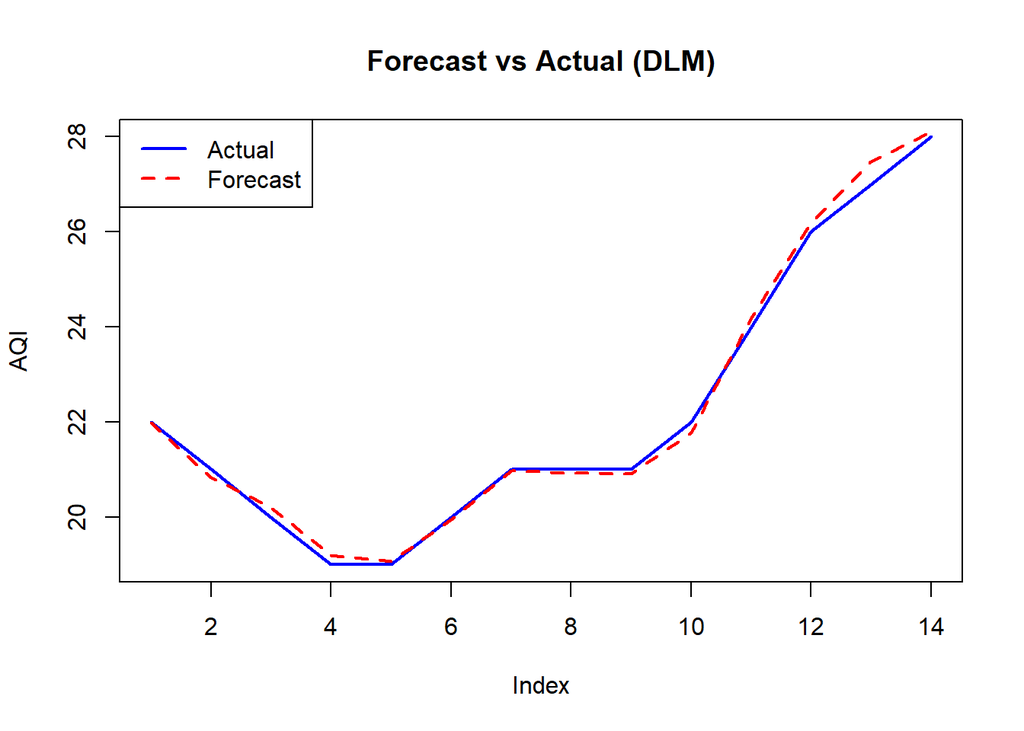

```r
# Ambil nilai prediksi dan aktual
y_pred_dlm <- as.vector(fore.dlm$forecasts)
y_true_dlm <- as.vector(test$AQI)

# Pastikan panjang sama
n <- min(length(y_pred_dlm), length(y_true_dlm))
y_pred_dlm <- y_pred_dlm[1:n]
y_true_dlm <- y_true_dlm[1:n]

# Plot
plot(y_true_dlm, type="l", col="blue", lwd=2,
     ylab="AQI", xlab="Index",
     main="Forecast vs Actual (DLM)")
lines(y_pred_dlm, col="red", lwd=2, lty=2)

legend("topleft", legend=c("Actual","Forecast"),
       col=c("blue","red"), lty=c(1,2), lwd=2)
```

MAPE = 0.64% -> model sangat baik. Model ini hampir perfect fit.

Garis merah (forecast) hampir berhimpit dengan garis biru (aktual).

Pola naik-turun AQI di setiap titik berhasil ditangkap dengan sangat baik oleh model.

Tidak terlihat perbedaan besar antara nilai prediksi dan aktual — menunjukkan error yang sangat kecil.

```r
GoF(model.dlm)
```

```
##            n       MAE          MPE        MAPE       sMAPE      MASE       MSE
## model.dlm 56 0.2659115 -0.000153498 0.009883436 0.009895147 0.4108184 0.1134602
##                 MRAE   GMRAE
## model.dlm 1020290187 5489.74
```

Kesalahan rata-rata sangat kecil (MAE & MAPE < 1%).

Tidak ada bias (MPE mendekati 0).

Performa lebih baik dibanding model naïf (MASE < 1).

Hasil ini konsisten dengan visual plot yang menunjukkan garis prediksi hampir berhimpit dengan aktual.

```r
#penentuan lag optimum
finiteDLMauto(formula = AQI ~ o3,
              data = data.frame(train), q.min = 1, q.max = 10,
              model.type = "dlm", error.type = "AIC", trace = TRUE)
```

```
##    q - k    MASE      AIC      BIC     GMRAE   MBRAE R.Adj.Sq  Ljung-Box
## 10    10 0.33647 24.10757 48.43318 10779.390 0.48008  0.98393 0.41122212
## 5      5 0.36542 27.02479 42.78712  6410.480 0.48192  0.98352 0.18919655
## 3      3 0.38312 27.10177 39.14577  5879.350 0.48128  0.98290 0.11147130
## 4      4 0.38276 27.96420 41.88709  7635.896 0.48443  0.98283 0.17399541
## 6      6 0.36302 29.64290 47.20409  4742.320 0.47166  0.98307 0.19759073
## 9      9 0.36482 30.09649 52.79833  8867.244 0.48588  0.98222 0.76300049
## 7      7 0.37392 30.57737 49.89563  5848.238 0.47755  0.98314 0.27764544
## 8      8 0.38196 31.33341 52.36567  8039.153 0.49778  0.98265 0.41731544
## 2      2 0.41082 47.04815 57.17490  5489.740 0.47425  0.97492 0.08786534
## 1      1 0.48746 91.76306 99.93527  5751.269 0.38586  0.94411 0.16242279
```

Berdasarkan output tersebut, lag optimum adalah 10.

```r
#model dlm dengan lag optimum
model.dlm2 <- dlm(x = train$o3,y = train$AQI , q = 10)
summary(model.dlm)
```

```
##
## Call:
## lm(formula = model.formula, data = design)
##
## Residuals:
##      Min       1Q   Median       3Q      Max
## -0.48041 -0.34171 -0.01844  0.25829  1.41892
##
## Coefficients:
##              Estimate Std. Error t value Pr(>|t|)
## (Intercept) -0.170522   0.676995  -0.252    0.802
## x.t          0.487583   0.052341   9.315 1.13e-12 ***
## x.1         -0.017540   0.098118  -0.179    0.859
## x.2         -0.005899   0.055262  -0.107    0.915
## ---
## Signif. codes:  0 '***' 0.001 '**' 0.01 '*' 0.05 '.' 0.1 ' ' 1
##
## Residual standard error: 0.3496 on 52 degrees of freedom
## Multiple R-squared:  0.9763, Adjusted R-squared:  0.9749
## F-statistic: 713.6 on 3 and 52 DF,  p-value: < 2.2e-16
##
## AIC and BIC values for the model:
##        AIC     BIC
## 1 47.04815 57.1749
```

```r
AIC(model.dlm2)
```

```
## [1] 24.10757
```

```r
BIC(model.dlm2)
```

```
## [1] 48.43318
```

F-statistic p-value < 2.2e-16 → model secara keseluruhan sangat signifikan.

AIC = 24.11, BIC = 48.43 → nilai ini rendah (bagus) dan lebih baik dibanding model q < 10

```r
fore.dlm2 <- forecast(model = model.dlm2, x=test$o3, h=h_test)

#akurasi data test
mape.dlm2<- MAPE(fore.dlm2$forecasts, test$AQI)
mape.dlm2
```

```
## [1] 0.0127254
```

Model model.dlm2 memberikan prediksi AQI yang sangat baik pada data test (akurasi ~98.7%).

### Model Autoregressive

```r
model.ardl <- ardlDlm(x = train$o3, y = train$AQI, p = 1 , q = 1)
summary(model.ardl)
```

```
##
## Time series regression with "ts" data:
## Start = 2, End = 58
##
## Call:
## dynlm(formula = as.formula(model.text), data = data, start = 1)
##
## Residuals:
##     Min      1Q  Median      3Q     Max
## -1.0233 -0.2713  0.1217  0.2984  0.8689
##
## Coefficients:
##             Estimate Std. Error t value Pr(>|t|)
## (Intercept) -0.24530    0.66489  -0.369    0.714
## X.t          0.48660    0.03236  15.036  < 2e-16 ***
## X.1         -0.23184    0.04540  -5.106 4.56e-06 ***
## Y.1          0.45632    0.06613   6.901 6.51e-09 ***
## ---
## Signif. codes:  0 '***' 0.001 '**' 0.01 '*' 0.05 '.' 0.1 ' ' 1
##
## Residual standard error: 0.3797 on 53 degrees of freedom
## Multiple R-squared:  0.9716, Adjusted R-squared:   0.97
## F-statistic: 604.7 on 3 and 53 DF,  p-value: < 2.2e-16
```

```r
AIC(model.ardl)
```

```
## [1] 57.2222
```

```r
BIC(model.ardl)
```

```
## [1] 67.43746
```

p-value F-statistic < 2.2e-16 → model secara keseluruhan sangat signifikan.

Adjusted R² = 0.97 → 97% variasi AQI pada data training bisa dijelaskan oleh variabel lagged AQI (Y.1) dan o3 (X.t dan X.1). Ini menunjukkan fit yang sangat baik.

O3 saat ini, o3 lag-1 dan AQI lag-1 signifikan.

Residual standard error = 0.3797 → error prediksi rata-rata kecil (cukup baik).

Residuals terlihat simetris (Min, Median, Max relatif seimbang).

AIC = 57.22, BIC = 67.44

```r
# Fit model pakai formula
modardl <- ardlDlm(AQI ~ o3, data = data, p = 1, q = 1)

# Data O3 ke depan (misalnya 14 observasi)
x_future <- test$o3[1:14]

# Forecast AQI ke depan
fore.ardl <- dLagM::forecast(modardl, x = x_future, h = 14)

fore.ardl
```

```
## $forecasts
##  [1] 21.92106 20.80730 20.17475 19.18631 19.04002 19.89849 20.91061 20.89829
##  [9] 20.89274 21.73661 24.09632 26.09796 27.41731 28.06441
##
## $call
## forecast.ardlDlm(model = modardl, x = x_future, h = 14)
##
## attr(,"class")
## [1] "forecast.ardlDlm" "dLagM"
```

```r
mape.ardl <- MAPE(fore.ardl$forecasts, test$AQI)
mape.ardl
```

```
## [1] 0.00644334
```

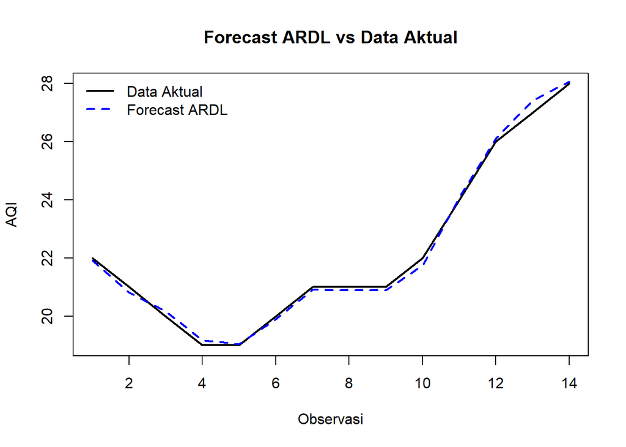

```r
# Plot hasil forecast vs data aktual
plot(
  test$AQI, type = "l", col = "black", lwd = 2,
  main = "Forecast ARDL vs Data Aktual",
  xlab = "Observasi", ylab = "AQI"
)
lines(fore.ardl$forecasts, col = "blue", lwd = 2, lty = 2)
legend(
  "topleft",
  legend = c("Data Aktual", "Forecast ARDL"),
  col = c("black", "blue"), lty = c(1, 2), lwd = 2, bty = "n"
)
```

Garis hitam = data aktual AQI

Garis biru putus-putus = hasil prediksi ARDL

Polanya hampir menyatu (hampir tidak ada gap), artinya model ARDL mampu mengikuti tren data aktual dengan sangat akurat.

Baik saat tren menurun (observasi 1–5) maupun tren naik (observasi 10–14), model tetap konsisten mengikuti perubahan AQI.

```r
#akurasi data training
GoF(model.ardl)
```

```
##             n       MAE           MPE       MAPE      sMAPE     MASE       MSE
## model.ardl 57 0.3138843 -0.0001781471 0.01165753 0.01164777 0.472514 0.1340668
##                  MRAE    GMRAE
## model.ardl 1108253474 6593.929
```

Model ARDL memberikan akurasi prediksi yang sangat tinggi (MAPE ≈ 1.17%, MAE ≈ 0.31).

Tidak ada indikasi bias, karena MPE mendekati nol.

```r
#penentuan lag optimum
model.ardl.opt <- ardlBoundOrders(data = data.frame(data), ic = "AIC",
                                  formula = AQI ~ o3 )
model.ardl.opt
```

```
## $p
##   o3
## 1 13
##
## $q
## [1] 2
##
## $Stat.table
##           q = 1    q = 2    q = 3    q = 4    q = 5    q = 6    q = 7    q = 8
## p = 1  38.64746 23.22848 25.42302 27.72031 28.70926 26.39158 27.98723 30.39158
## p = 2  22.86594 24.77455 27.31646 28.69429 28.81115 25.64963 27.33061 30.08845
## p = 3  27.18085 27.18085 28.84077 30.37243 30.71504 25.55412 27.74318 30.55048
## p = 4  27.27918 28.33392 28.33392 27.22651 29.94853 27.52594 29.31474 32.19458
## p = 5  28.22371 28.68011 29.37749 29.37749 30.12962 28.60210 31.06991 33.54724
## p = 6  27.11336 28.13965 27.00217 28.68077 28.68077 30.47844 33.06989 35.19285
## p = 7  30.19026 30.92504 29.24074 30.23773 30.81010 30.81010 29.56882 27.97012
## p = 8  26.81548 26.88306 26.96639 27.84677 26.80343 28.40155 28.40155 29.27146
## p = 9  25.15641 25.64777 25.75789 27.48094 26.12645 27.83358 29.58776 29.58776
## p = 10 28.59615 28.86775 29.29778 31.09265 28.82957 30.63888 32.57903 34.34994
## p = 11 24.53224 23.37847 24.80335 26.48648 23.35632 25.20746 26.60810 26.81938
## p = 12 27.14281 25.70395 27.06234 28.84787 26.03408 27.92602 28.91965 28.33033
## p = 13 19.25858 16.55044 18.53543 20.33824 17.61125 19.60705 21.03414 21.71506
## p = 14 20.31747 18.36045 20.36004 22.34912 19.16521 21.06710 22.41853 23.18530
## p = 15 22.41646 20.32505 22.22270 24.14701 21.64522 23.25026 24.97916 26.17790
##           q = 9   q = 10   q = 11   q = 12   q = 13   q = 14   q = 15
## p = 1  33.09252 33.18190 32.84415 33.19542 35.85663 30.71580 27.67083
## p = 2  32.80513 33.98671 32.34936 32.42167 35.04537 31.25200 27.25097
## p = 3  33.31925 34.28268 33.42041 33.94715 36.44309 32.48438 28.87461
## p = 4  34.95803 36.14844 35.27999 35.94335 38.39874 34.28870 30.56428
## p = 5  36.11311 37.41170 36.41377 37.18234 39.82841 36.17273 32.18350
## p = 6  35.88842 36.25737 35.13490 36.94569 39.67535 32.69633 29.29501
## p = 7  30.90878 33.89102 34.52801 36.37243 38.74818 31.23844 29.15791
## p = 8  31.44233 34.39275 26.01225 26.78247 27.92580 24.10080 23.75594
## p = 9  31.57509 33.98987 27.47278 26.92081 26.62574 21.91896 21.71187
## p = 10 34.34994 33.75383 24.46154 25.13892 26.98653 23.27262 23.65748
## p = 11 23.68447 23.68447 24.90968 27.13805 28.98636 25.18996 25.61717
## p = 12 25.59091 27.59091 27.59091 29.08999 29.84364 23.51211 22.55179
## p = 13 19.56880 19.27526 21.04212 21.04212 22.98266 23.87236 23.91841
## p = 14 22.81463 22.84285 24.84274 22.27955 22.27955 24.27951 25.89778
## p = 15 25.36264 24.86236 26.81668 26.73848 27.78117 27.78117 27.75060
##
## $min.Stat
## [1] 16.55044
```

```r
min_p=c()
for(i in 1:15){
  min_p[i]=min(model.ardl.opt$Stat.table[[i]])
}
q_opt=which(min_p==min(min_p, na.rm = TRUE))
p_opt=which(model.ardl.opt$Stat.table[[q_opt]] ==
              min(model.ardl.opt$Stat.table[[q_opt]], na.rm = TRUE))
data.frame("q_optimum" = q_opt, "p_optimum" = p_opt,
           "AIC"=model.ardl.opt$min.Stat)
```

```
##   q_optimum p_optimum      AIC
## 1         2        13 16.55044
```

Didapatkan q optimum = 2 dan p optimum = 13

```r
model.ardl2 <- ardlDlm(formula = AQI ~ o3,
                         data = train,p = 2, q = 13)
summary(model.ardl2)
```

```
##
## Time series regression with "ts" data:
## Start = 14, End = 58
##
## Call:
## dynlm(formula = as.formula(model.text), data = data)
##
## Residuals:
##      Min       1Q   Median       3Q      Max
## -0.48900 -0.22295 -0.01183  0.19326  0.47401
##
## Coefficients:
##              Estimate Std. Error t value Pr(>|t|)
## (Intercept) -1.237853   1.191574  -1.039    0.308
## o3.t         0.455077   0.086392   5.268 1.33e-05 ***
## o3.1         0.134293   0.228457   0.588    0.561
## o3.2         0.002710   0.224250   0.012    0.990
## AQI.1       -0.205269   0.191777  -1.070    0.294
## AQI.2       -0.009811   0.194528  -0.050    0.960
## AQI.3       -0.014613   0.158955  -0.092    0.927
## AQI.4       -0.064092   0.121946  -0.526    0.603
## AQI.5        0.070824   0.123267   0.575    0.570
## AQI.6       -0.083122   0.117381  -0.708    0.485
## AQI.7        0.086451   0.113824   0.760    0.454
## AQI.8       -0.027234   0.111727  -0.244    0.809
## AQI.9       -0.018867   0.110882  -0.170    0.866
## AQI.10       0.082003   0.101493   0.808    0.426
## AQI.11      -0.084207   0.104545  -0.805    0.427
## AQI.12      -0.037109   0.104337  -0.356    0.725
## AQI.13       0.064659   0.063802   1.013    0.320
## ---
## Signif. codes:  0 '***' 0.001 '**' 0.01 '*' 0.05 '.' 0.1 ' ' 1
##
## Residual standard error: 0.317 on 28 degrees of freedom
## Multiple R-squared:  0.9867, Adjusted R-squared:  0.9791
## F-statistic: 129.6 on 16 and 28 DF,  p-value: < 2.2e-16
```

```r
AIC(model.ardl2)
```

```
## [1] 38.95242
```

```r
BIC(model.ardl2)
```

```
## [1] 71.47234
```

R-squared = 0.9867 → model mampu menjelaskan 98.67% variasi AQI dengan variabel o3 (dan lag-lagnya) serta lag AQI.

Adjusted R-squared = 0.9791 → nilai masih sangat tinggi, artinya model tetap baik meskipun mempertimbangkan jumlah variabel (lag yang banyak).

o3.t (lag 0) signifikan pada p-value < 0.001 (sangat signifikan), sehingga konsentrasi O₃ saat ini berpengaruh besar terhadap AQI.

Sebagian besar lag o3 (o3.1, o3.2) dan lag AQI (AQI.1 … AQI.13) tidak signifikan (p-value > 0.05). ➝ Ini berarti efek keterlambatan (lag effect) dari O₃ maupun AQI sebelumnya tidak terlalu berkontribusi terhadap AQI saat ini.

Hanya efek current O₃ yang dominan.

F-statistic = 129.6, p-value < 2.2e-16 → model secara keseluruhan sangat signifikan.

AIC = 38.95, BIC = 71.47 → cukup rendah, menunjukkan model dengan lag panjang ini relatif baik.

RSE = 0.317 → menunjukkan error model kecil, mendukung ketepatan model.

```r
fore.ardl2 <- forecast(model = model.ardl2, x=test$o3, h=h_test)
fore.ardl2
```

```
## $forecasts
##  [1] 21.87823 20.69245 19.93376 19.19186 18.77571 19.62386 20.76029 20.84163
##  [9] 20.74772 21.48635 23.90267 26.04110 27.42544 28.12860
##
## $call
## forecast.ardlDlm(model = model.ardl2, x = test$o3, h = h_test)
##
## attr(,"class")
## [1] "forecast.ardlDlm" "dLagM"
```

```r
mape.ardl2 <- MAPE(fore.ardl2$forecasts, test$AQI)
mape.ardl2
```

```
## [1] 0.01032181
```

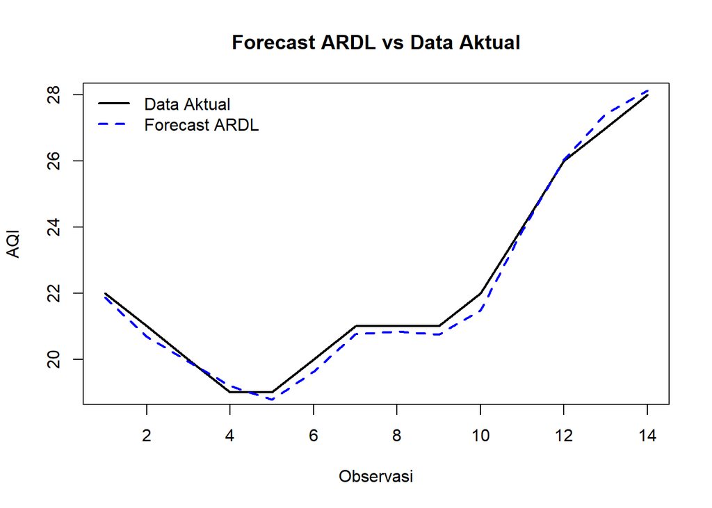

```r
plot(
  test$AQI, type = "l", col = "black", lwd = 2,
  main = "Forecast ARDL vs Data Aktual",
  xlab = "Observasi", ylab = "AQI"
)
lines(fore.ardl2$forecasts, col = "blue", lwd = 2, lty = 2)
legend(
  "topleft",
  legend = c("Data Aktual", "Forecast ARDL"),
  col = c("black", "blue"), lty = c(1, 2), lwd = 2, bty = "n"
)
```

MAPE = 0.0103 (≈ 1.03%)

Ini sangat kecil → artinya model ARDL2 memiliki akurasi prediksi yang sangat baik pada data test.

Model fit sangat baik → tidak ada deviasi besar antara prediksi dan aktual.

MAPE yang kecil (≈ 1%) juga mendukung hasil ini.

Pola naik di observasi 10–14 berhasil diikuti dengan baik oleh model, tidak ada lagging signifikan.

```r
GoF(model.ardl2)
```

```
##              n     MAE           MPE        MAPE      sMAPE      MASE
## model.ardl2 45 0.21365 -8.576615e-05 0.007822173 0.00782468 0.3916916
##                    MSE       MRAE    GMRAE
## model.ardl2 0.06252006 1106151349 24614.64
```

Error < 1% (MAPE) → prediksi hampir sempurna.

Tidak ada bias signifikan (MPE ≈ 0).

Lebih baik daripada model naive (MASE < 1).

### Pemodelan DLM & ARDL dengan Library dynlm

```r
#sama dengan ardl p=13 q=2
cons_lm3 <- dynlm(AQI ~ L(AQI, 1:13)+L(o3, 0:2),data = train.ts)
#sama dengan dlm p=10
cons_lm4 <- dynlm(AQI ~ o3 + L(o3, 1:10), data = train.ts)
```

```r
summary(cons_lm3)
```

```
##
## Time series regression with "ts" data:
## Start = 14, End = 58
##
## Call:
## dynlm(formula = AQI ~ L(AQI, 1:13) + L(o3, 0:2), data = train.ts)
##
## Residuals:
##      Min       1Q   Median       3Q      Max
## -0.48900 -0.22295 -0.01183  0.19326  0.47401
##
## Coefficients:
##                 Estimate Std. Error t value Pr(>|t|)
## (Intercept)    -1.237853   1.191574  -1.039    0.308
## L(AQI, 1:13)1  -0.205269   0.191777  -1.070    0.294
## L(AQI, 1:13)2  -0.009811   0.194528  -0.050    0.960
## L(AQI, 1:13)3  -0.014613   0.158955  -0.092    0.927
## L(AQI, 1:13)4  -0.064092   0.121946  -0.526    0.603
## L(AQI, 1:13)5   0.070824   0.123267   0.575    0.570
## L(AQI, 1:13)6  -0.083122   0.117381  -0.708    0.485
## L(AQI, 1:13)7   0.086451   0.113824   0.760    0.454
## L(AQI, 1:13)8  -0.027234   0.111727  -0.244    0.809
## L(AQI, 1:13)9  -0.018867   0.110882  -0.170    0.866
## L(AQI, 1:13)10  0.082003   0.101493   0.808    0.426
## L(AQI, 1:13)11 -0.084207   0.104545  -0.805    0.427
## L(AQI, 1:13)12 -0.037109   0.104337  -0.356    0.725
## L(AQI, 1:13)13  0.064659   0.063802   1.013    0.320
## L(o3, 0:2)0     0.455077   0.086392   5.268 1.33e-05 ***
## L(o3, 0:2)1     0.134293   0.228457   0.588    0.561
## L(o3, 0:2)2     0.002710   0.224250   0.012    0.990
## ---
## Signif. codes:  0 '***' 0.001 '**' 0.01 '*' 0.05 '.' 0.1 ' ' 1
##
## Residual standard error: 0.317 on 28 degrees of freedom
## Multiple R-squared:  0.9867, Adjusted R-squared:  0.9791
## F-statistic: 129.6 on 16 and 28 DF,  p-value: < 2.2e-16
```

```r
summary(cons_lm4)
```

```
##
## Time series regression with "ts" data:
## Start = 11, End = 58
##
## Call:
## dynlm(formula = AQI ~ o3 + L(o3, 1:10), data = train.ts)
##
## Residuals:
##      Min       1Q   Median       3Q      Max
## -0.48304 -0.17355  0.04636  0.17934  0.52554
##
## Coefficients:
##               Estimate Std. Error t value Pr(>|t|)
## (Intercept)   -0.64267    0.89957  -0.714  0.47958
## o3             0.42814    0.06180   6.928 4.08e-08 ***
## L(o3, 1:10)1   0.13889    0.13339   1.041  0.30473
## L(o3, 1:10)2  -0.05734    0.12788  -0.448  0.65654
## L(o3, 1:10)3  -0.14994    0.12237  -1.225  0.22840
## L(o3, 1:10)4   0.15911    0.12493   1.274  0.21095
## L(o3, 1:10)5  -0.01335    0.12436  -0.107  0.91510
## L(o3, 1:10)6  -0.12709    0.12430  -1.022  0.31338
## L(o3, 1:10)7   0.27371    0.12253   2.234  0.03180 *
## L(o3, 1:10)8  -0.37459    0.12097  -3.097  0.00378 **
## L(o3, 1:10)9   0.28924    0.10409   2.779  0.00862 **
## L(o3, 1:10)10 -0.09537    0.04837  -1.971  0.05640 .
## ---
## Signif. codes:  0 '***' 0.001 '**' 0.01 '*' 0.05 '.' 0.1 ' ' 1
##
## Residual standard error: 0.2739 on 36 degrees of freedom
## Multiple R-squared:  0.9877, Adjusted R-squared:  0.9839
## F-statistic: 262.6 on 11 and 36 DF,  p-value: < 2.2e-16
```

```r
deviance(cons_lm3)
```

```
## [1] 2.813403
```

2.813403 adalah total kuadrat dari selisih antara nilai aktual AQI dengan nilai prediksi model cons_lm3.

```r
deviance(cons_lm4)
```

```
## [1] 2.701746
```

2.701746 adalah total kuadrat dari selisih antara nilai aktual AQI dengan nilai prediksi model cons_lm4.

```r
dwtest(cons_lm3)
```

```
##
##  Durbin-Watson test
##
## data:  cons_lm3
## DW = 1.9978, p-value = 0.3242
## alternative hypothesis: true autocorrelation is greater than 0
```

Nilai DW ≈ 2 → Ini indikasi tidak ada autokorelasi pada residual.

p-value = 0.3242 > 0.05 → gagal menolak H₀, sehingga tidak ada bukti signifikan adanya autokorelasi positif.

Kesimpulan: Residual dari model cons_lm3 bersifat independen (tidak berkorelasi secara signifikan antar waktu), artinya model ini sudah cukup baik dari sisi asumsi independensi error.

```r
dwtest(cons_lm4)
```

```
##
##  Durbin-Watson test
##
## data:  cons_lm4
## DW = 2.1908, p-value = 0.5901
## alternative hypothesis: true autocorrelation is greater than 0
```

Nilai DW ≈ 2 → Ini indikasi tidak ada autokorelasi pada residual.

p-value = 0.5901 > 0.05 → gagal menolak H₀, sehingga tidak ada bukti signifikan adanya autokorelasi positif.

Kesimpulan: Residual dari model cons_lm4 bersifat independen (tidak berkorelasi secara signifikan antar waktu), artinya model ini sudah cukup baik dari sisi asumsi independensi error.

```r
bptest(cons_lm3)
```

```
##
##  studentized Breusch-Pagan test
##
## data:  cons_lm3
## BP = 15.088, df = 16, p-value = 0.5182
```

Tidak ada bukti signifikan adanya heteroskedastisitas.

```r
bptest(cons_lm4)
```

```
##
##  studentized Breusch-Pagan test
##
## data:  cons_lm4
## BP = 9.774, df = 11, p-value = 0.5508
```

Tidak ada bukti signifikan adanya heteroskedastisitas.

```r
shapiro.test(residuals(cons_lm3))
```

```
##
##  Shapiro-Wilk normality test
##
## data:  residuals(cons_lm3)
## W = 0.96659, p-value = 0.2168
```

Residual cons_lm3 dapat dianggap berdistribusi normal.

```r
shapiro.test(residuals(cons_lm4))
```

```
##
##  Shapiro-Wilk normality test
##
## data:  residuals(cons_lm4)
## W = 0.96818, p-value = 0.2149
```

Residual cons_lm4 dapat dianggap berdistribusi normal.

```r
akurasi <- matrix(c(mape.koyck, mape.dlm, mape.dlm2, mape.ardl, mape.ardl2))
row.names(akurasi)<- c("Koyck","DLM 1","DLM 2","Autoregressive 1", "Autoregressive 2")
colnames(akurasi) <- c("MAPE")
akurasi
```

```
##                          MAPE
## Koyck            49.908852257
## DLM 1             0.006409836
## DLM 2             0.012725396
## Autoregressive 1  0.006443340
## Autoregressive 2  0.010321807
```

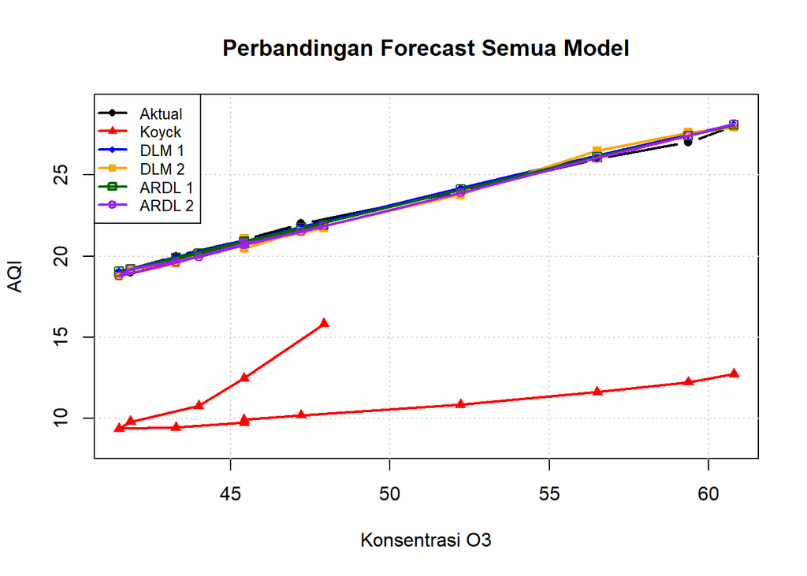

```r
par(mfrow=c(1,1))

# Sesuaikan skala sumbu Y agar fokus ke rentang AQI sebenarnya
y_min <- min(c(test$AQI, fore.koyck$forecasts, fore.dlm$forecasts,
               fore.dlm2$forecasts, fore.ardl$forecasts, fore.ardl2$forecasts))
y_max <- max(c(test$AQI, fore.koyck$forecasts, fore.dlm$forecasts,
               fore.dlm2$forecasts, fore.ardl$forecasts, fore.ardl2$forecasts))

plot(test$o3, test$AQI, type="b", col="black", pch=16, lwd=2,
     ylim=c(y_min-1, y_max+1),  # otomatis mengikuti data
     xlab="Konsentrasi O3", ylab="AQI",
     main="Perbandingan Forecast Semua Model")
grid()

# Tambahkan garis forecast tiap model
lines(test$o3, fore.koyck$forecasts, col="red", lwd=2)
points(test$o3, fore.koyck$forecasts, col="red", pch=17)

lines(test$o3, fore.dlm$forecasts, col="blue", lwd=2)
points(test$o3, fore.dlm$forecasts, col="blue", pch=18)

lines(test$o3, fore.dlm2$forecasts, col="orange", lwd=2)
points(test$o3, fore.dlm2$forecasts, col="orange", pch=15)

lines(test$o3, fore.ardl$forecasts, col="darkgreen", lwd=2)
points(test$o3, fore.ardl$forecasts, col="darkgreen", pch=0)

lines(test$o3, fore.ardl2$forecasts, col="purple", lwd=2)
points(test$o3, fore.ardl2$forecasts, col="purple", pch=1)

legend("topleft",
       c("Aktual", "Koyck", "DLM 1", "DLM 2", "ARDL 1", "ARDL 2"),
       lty=1, col=c("black","red","blue","orange","darkgreen","purple"),
       pch=c(16,17,18,15,0,1), lwd=2, cex=0.8, bg="white")
```

Berdasarkan plot, seluruh model selain model Koyck mendekati data aktual.